# 跨球館實力評分：階層模型與冷啟動

StatSoft 期末專題：R 實質任務（平台版）

2026-11-26

# 1 問題

專題從政大野場擴大成**全台跨球館的報名平台**：每個人一份個人檔案，在不同球館打球的紀錄都累積起來，由統計模型算出「你到底是什麼程度」。這帶來三個單一球館時沒有的統計問題：

1. **各館不在同一把尺上。** 每間球館的分級是自己定的，A 館的「4 級」可能是 B 館的「3 級」；同一局兩隊一定在同一館，比賽結果只能比較同館的人。不同館要怎麼比？
2. **新人冷啟動。** 剛建立檔案的人只有自報程度。要打幾局，系統才「認識」他？自報錯了，多久會被修正？
3. **自我認知偏誤。** 誰容易高估自己？能不能從資料看出來？

模型延續單館版（`report.html`）的逐球 Bradley–Terry，以下只說明新增的部分。

# 2 模型：球館隨機效果

$$\operatorname{logit} P(\text{A 隊得一分}) = \bar\theta_A - \bar\theta_B
+ \delta\,(n_A - n_B)$$
$$\theta_i \sim N\big(\alpha_{h(i)} + \beta\,(\text{自報}_i - 3),\
\sigma^2\big),\qquad \alpha_v \sim N(0, \sigma_v^2)$$

- $h(i)$ 是球員 $i$ 的**主場**球館，$\alpha_v$ 是該館球員的平均實力（例如有校隊常駐的館較強）。
- 球館**不進比賽式**：同一局兩隊同館，館的效果會相消。球館只透過「誰的主場在哪」影響先驗。
- 不同館能放在同一把尺上，靠的是到多個球館打球的**橋接球員**：他在 A 館贏多少、在 B 館贏多少，就把兩館連起來。沒有橋接球員時，$\alpha_v$ 只剩先驗，模型會誠實地給出很寬的區間。
- $\sigma, \sigma_v$ 一樣用 Laplace 邊際概似估計（經驗貝氏）；資料顯示各館差不多時，$\hat\sigma_v \to 0$，模型自動退回單館版。

程式：`R/platform_model.R` 的 `fit_platform_model()`。

# 3 跨館比較：要多少橋接球員？

## 3.1 設計

5 間球館、每館 40 位主場球員；各館平均實力 $\alpha_v \sim N(0, 0.4^2)$。**各館自己分級**：自報程度只跟同館的人比（這正是現實中跨館不可比的原因）。每館 16 晚、每晚 12 局。跑館比例 0%、2%、5%、10%、20%，各重複 100 次。另外做一組「全台同一套分級」當對照。

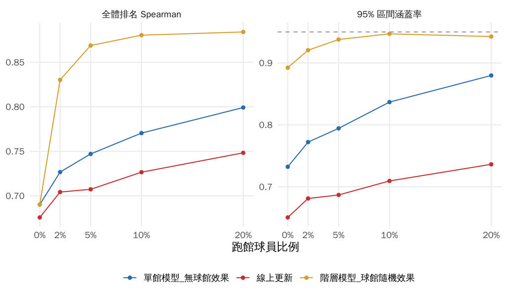

左：所有球員（跨館）的估計實力排名與真實排名的 Spearman 相關。右：球員 95% 區間的實際涵蓋率。

| 分級 | 跑館比例 | 橋接人數 | 模型 | Spearman | 涵蓋率 | 球館平均 RMSE | 球館區間涵蓋率 |
| --- | --- | --- | --- | --- | --- | --- | --- |
| 各館自己分級 | 0% | 0.0 | 單館模型_無球館效果 | 0.69 | 73.2% |  |  |
| 各館自己分級 | 0% | 0.0 | 線上更新 | 0.68 | 65.0% |  |  |
| 各館自己分級 | 0% | 0.0 | 階層模型_球館隨機效果 | 0.69 | 89.2% | 0.34 | 86% |
| 各館自己分級 | 2% | 3.9 | 單館模型_無球館效果 | 0.73 | 77.2% |  |  |
| 各館自己分級 | 2% | 3.9 | 線上更新 | 0.70 | 68.1% |  |  |
| 各館自己分級 | 2% | 3.9 | 階層模型_球館隨機效果 | 0.83 | 92.0% | 0.20 | 79% |
| 各館自己分級 | 5% | 9.7 | 單館模型_無球館效果 | 0.75 | 79.4% |  |  |
| 各館自己分級 | 5% | 9.7 | 線上更新 | 0.71 | 68.7% |  |  |
| 各館自己分級 | 5% | 9.7 | 階層模型_球館隨機效果 | 0.87 | 93.8% | 0.14 | 85% |
| 各館自己分級 | 10% | 20.5 | 單館模型_無球館效果 | 0.77 | 83.7% |  |  |
| 各館自己分級 | 10% | 20.5 | 線上更新 | 0.73 | 70.9% |  |  |
| 各館自己分級 | 10% | 20.5 | 階層模型_球館隨機效果 | 0.88 | 94.7% | 0.10 | 91% |
| 各館自己分級 | 20% | 39.4 | 單館模型_無球館效果 | 0.80 | 88.0% |  |  |
| 各館自己分級 | 20% | 39.4 | 線上更新 | 0.75 | 73.6% |  |  |
| 各館自己分級 | 20% | 39.4 | 階層模型_球館隨機效果 | 0.88 | 94.3% | 0.09 | 94% |
| 全台同一分級 | 10% | 20.3 | 單館模型_無球館效果 | 0.85 | 90.9% |  |  |
| 全台同一分級 | 10% | 20.3 | 線上更新 | 0.81 | 79.5% |  |  |
| 全台同一分級 | 10% | 20.3 | 階層模型_球館隨機效果 | 0.87 | 94.3% | 0.18 | 67% |

重點：

- **不加球館效果，跨館排名會錯，而且錯得很有自信。** 單館模型把各館的「4 級」當成一樣，Spearman 只有 0.77，區間涵蓋率只有 84%。
- **階層模型在 5% 跑館（每館約 2 人）時就大幅改善**（Spearman 0.87），10% 時 0.88、球館平均的誤差約 0.10。
- **完全沒有跑館的人（0%）時，模型無法比較各館**，但它會誠實地把區間放寬，涵蓋率仍有 89%。這對平台的意義是：跨館排名的可信度取決於有多少人跨館，系統應該顯示這個不確定性，而不是假裝知道。
- 若全台用同一套分級，自報本身就部分把各館連起來，兩個模型差距縮小（表格最後兩列：0.85 vs 0.87）。

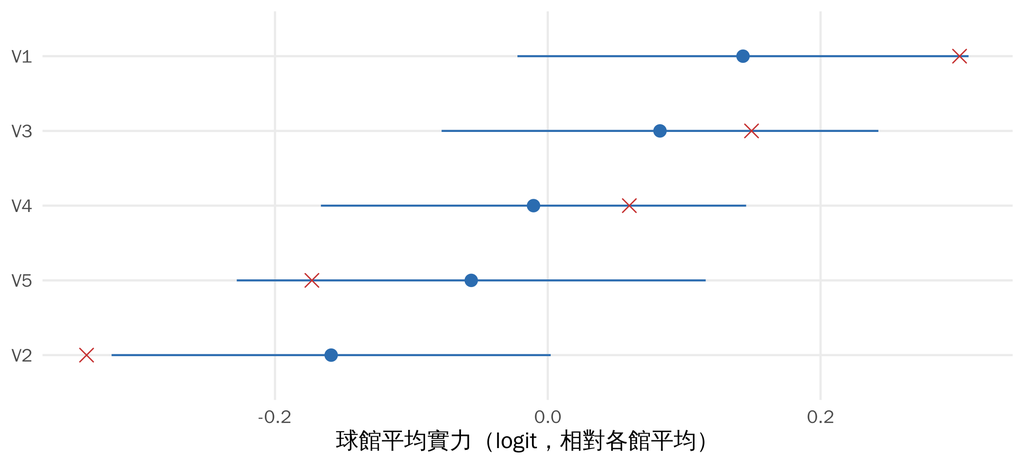

示範資料（跑館 10%）：各館平均實力的估計值與 95% 區間（點），× 為真值。

# 4 冷啟動：新人要打幾局？

## 4.1 線上更新演算法

平台不可能每打一局就重跑整個模型，所以另外寫了**每局即時更新**的版本（`online_update()`）：每個人只存實力的平均 $\mu$ 和變異數 $v$。新人以先驗開始：$\mu = \hat\alpha_{\text{主場}} + \hat\beta(\text{自報} - 3)$，$v = \hat\sigma^2$。每打完一局：

$$v_j \leftarrow \Big(\frac{1}{v_j} + w_j^2\,\kappa^2 N
p(1-p)\Big)^{-1},\qquad
\mu_j \leftarrow \mu_j \pm v_j\, w_j\,\kappa\,(a - Np)$$

其中 $N$ 是該局總球數、$a$ 是 A 隊得分、$p$ 是賽前預測的每球得分機率、$w_j = 1/\text{隊伍人數}$、$\kappa$ 是考慮隊伍實力不確定性的修正。這是對貝氏後驗的 Laplace 近似（假設密度濾波），與 Glicko 評分同一家族。

## 4.2 設計

先模擬一間球館 40 人打 16 晚，用批次模型估出老球員實力。接著讓 400 位新人各自加入，每晚和隨機 24 位老球員分 5 隊打 12 局（新人平均每晚上場約 4.8 局），追蹤 15 晚。同一批新人、同一串比賽，比較四種先驗：自報準確、**高估 2 級**、**低估 2 級**、不填自報。

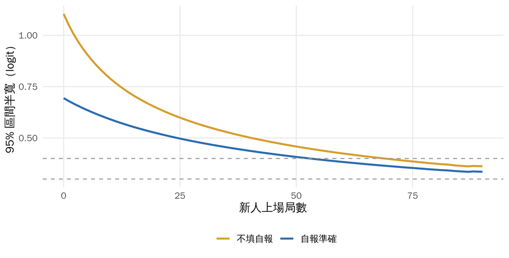

新人 95% 區間半寬隨上場局數縮小。虛線：半寬 0.4（約一個自報級距）與 0.3。

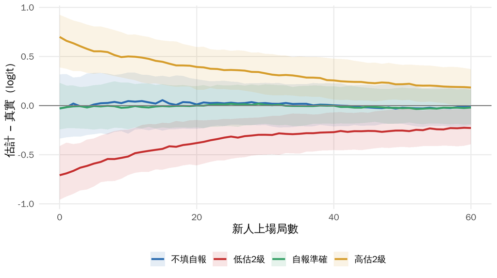

估計值減真實實力（中位數與 25–75% 範圍）。自報錯 2 級的人，系統要多久才修正？

結論：

- **區間收斂得慢。** 自報準確的新人，一開始 95% 區間半寬 0.69，打 53 局（約 11 晚）才縮到 0.4（約一個級距）。原因是一局只有一個比分，卻要分給 4–6 位隊友：個人的資訊被稀釋了。
- **自報很值錢。** 不填自報的人要打 69 局才達到同樣的寬度；換句話說，一個大致誠實的自報，抵得上 16 局左右的比賽資料。
- **自報錯 2 級，大約 29 局（6 晚）修正一半**；高估與低估的修正速度差不多（低估：25 局）。
- **對平台設計的建議**：新人前幾晚應該讓報名門檻放寬（用區間下限或上限判斷），或請新人先打「定級場」；系統顯示等級時應同時顯示「可信度」（例如已打局數或區間寬度）。

線上更新給新人的 95% 區間略偏窄：自報準確或不填自報時，實際涵蓋率約 89%；自報錯 2 級的人只有約 68%，因為先驗本身就錯了，區間在修正完成前會「自信地錯」。所以前幾晚的等級只能當參考，這也支持上面「定級場」的建議。

# 5 線上更新 vs 批次模型

| 跑館比例 | 線上 Spearman | 批次 Spearman | 線上涵蓋率 | 批次涵蓋率 | 線上與批次估計的相關 |
| --- | --- | --- | --- | --- | --- |
| 0% | 0.68 | 0.69 | 65% | 89% | 0.98 |
| 2% | 0.70 | 0.83 | 68% | 92% | 0.86 |
| 5% | 0.71 | 0.87 | 69% | 94% | 0.83 |
| 10% | 0.73 | 0.88 | 71% | 95% | 0.85 |
| 20% | 0.75 | 0.88 | 74% | 94% | 0.87 |

線上版只掃過資料一次、而且不知道球館效果，所以排序比批次版差，區間也**太窄**（涵蓋率明顯低於 95%：它把每局都當成獨立的新資訊，忽略了隊友估計之間的相關）。**建議的平台架構**：每局用線上更新即時顯示，每晚關館後用批次階層模型重估一次、覆蓋線上結果，並更新 $\hat\alpha, \hat\beta, \hat\sigma$。

# 6 套用到 Python 跨球館模擬資料

另一條工作線的 Python 模擬器（`volley-sim/platform`）有 4 間球館（含政大野場）、150 人、8 週，各館賽制、報名門檻、自評文化都不同，自報偏誤還跟性別、球齡有關。它的機制和本模型不同，是「模型設定不完全正確」的考驗。

| 跨館比例 | 模型 | 局數 | 橋接人數 | Spearman | 涵蓋率* | 球館平均誤差* | σv 估計 |
| --- | --- | --- | --- | --- | --- | --- | --- |
| 0% | 階層模型_球館隨機效果 | 788 | 0 | 0.78 | 100% | 0.10 | 0.30 |
| 0% | 單館模型_無球館效果 | 788 | 0 | 0.78 | 97% | 0.10 |  |
| 10% | 階層模型_球館隨機效果 | 772 | 17 | 0.86 | 98% | 0.18 | 0.35 |
| 10% | 單館模型_無球館效果 | 772 | 17 | 0.86 | 100% | 0.03 |  |
| 30% | 階層模型_球館隨機效果 | 783 | 42 | 0.85 | 99% | 0.07 | 0.14 |
| 30% | 單館模型_無球館效果 | 783 | 42 | 0.83 | 99% | 0.04 |  |

* Python 模擬器的實力尺度和模型不同，先以線性迴歸把真值換到模型尺度再計算。

- 三種跨館比例下排名相關都在 0.78–0.86，區間涵蓋率接近或高於 95%。
- 在這份資料裡**階層模型沒有比較好**，甚至把進階館（V03）和新手館（V04）跟政大的差距都估得太大。原因：Python 模擬器的自報程度是「全台同一把尺再加上自評文化偏誤」，自報本身已經把各館連起來（相當於第 3 節「全台同一分級」的情境）；再加上它的逐球引擎與 logit 線性假設不同，強館之間的差距被放大。
- **所以要不要球館效果，取決於各館分級能不能互相比較**。平台上線時無法事先知道，所以保留階層模型，讓 $\hat\sigma_v$ 由資料決定，同時把「跨館差距」列為需要真實資料檢驗的限制。

## 6.1 自我認知偏誤：Bland–Altman 與誤差迴歸

為了避免循環論證，這裡的實力估計**不使用自報先驗**（只用比賽結果＋球館效果）。用全體的「自報 ~ 估計實力」校準線，把估計實力換成「應有級數」，再看自報減應有級數。

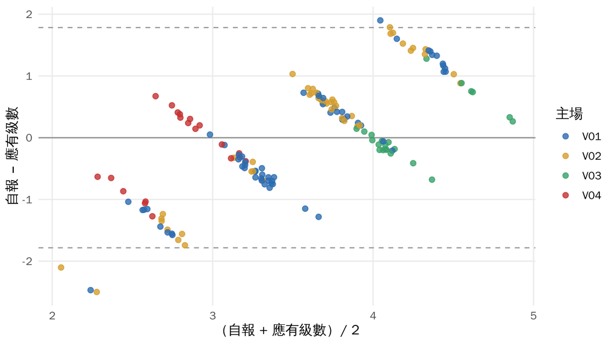

Bland–Altman 圖：橫軸為自報與應有級數的平均，縱軸為差（正 = 高估自己）。虛線為平均差與 95% 一致性界限。

誤差迴歸：自報 − 應有級數 ~ 性別 + 球齡 + 主場（括號為標準誤）

| 變數 | 用估計實力 | 用真實實力（只有模擬才有） |
| --- | --- | --- |
| (截距) | 0.02 (0.21) | 0.14 (0.17) |
| 男性 | -0.03 (0.15) | 0.02 (0.12) |
| 球齡（每年） | -0.03 (0.04) | -0.06 (0.03) |
| 主場 V02 | 0.32 (0.18) | 0.24 (0.14) |
| 主場 V03 | 0.19 (0.23) | 0.16 (0.18) |
| 主場 V04 | -0.10 (0.24) | -0.12 (0.19) |

- 用估計實力算出的「每個人高估多少」，和用真實實力算的相關 0.88：**個人層級的高估／低估抓得到**，可以當作平台提醒（例如「你的自報比比賽結果高 1 級」）。
- 但**群體層級的效果（男性、球齡、球館文化）在 150 人時大多不顯著**，即使用真實實力也一樣；這是樣本數不夠、檢定力不足，不是方法錯。報告中可以說明需要多少人才偵測得到。

# 7 結論與限制

1. 跨球館平台需要**球館隨機效果**，否則各館自己分級時，跨館排名會錯而且區間過窄。
2. 跨館比較靠**橋接球員**：每館約 2–4 人跨館就有明顯改善；沒有人跨館時，模型會誠實地表示無法比較。
3. **冷啟動慢**：一般新人約 53 局（11 晚）後區間才縮到一個級距；自報錯 2 級要約 29 局修正一半。自報先驗大約省下 16 局。
4. 平台建議：**即時線上更新 + 每晚批次重估**；等級旁邊顯示可信度。
5. 限制：模擬參數是假設；Python 資料顯示當逐球機制非 logit 線性時，強館差距可能被高估；實力假設不隨時間改變（可加 drift，`online_run(drift = )` 已預留）。

**重現**

```
R_REPS=100 Rscript analysis/04_platform_venues.R   # 4 核心約 10 分鐘
N_NEW=400  Rscript analysis/05_cold_start.R        # 約 20 秒
Rscript analysis/06_platform_python.R              # 需要 volley-sim/platform 資料
Rscript -e 'rmarkdown::render("platform_report.Rmd")'
```